# Case Study1 Project

Lauren Darr, Emmanuel Farrugia, John Heinen, Johnson Ekedum

12 March, 2017

## Introduction

The data project seeks to explore world economic and social indicators of major countries. In this project, our goal is to carry out an exploratory data analysis using two data set, GDP data and Educational data.This data will be downloaded from the world bank website. Original data set are in the links below

- [GDP data](http://data.worldbank.org/data-catalog/GDP-ranking-table)
- [Education data](http://data.worldbank.org/data-catalog/ed-stats)

##### In this project we will go through a 3 step process which will invlove

- Cleaning dataset
- Analysing dataset
- Visualizing data set

To begin we will load the required package and download the dataset into R.

- Loading required package:Please install first if you dont have them

```r
knitr::opts_chunk$set(echo = TRUE)
library(readr)
library(dplyr)
library(ggplot2)
library(stringr)
library(data.table)
library(Hmisc)
```

Download data from URL

```r
GDPurl <-  "https://d396qusza40orc.cloudfront.net/getdata%2Fdata%2FGDP.csv"
download.file(GDPurl, "GDP.csv", quiet=TRUE)

EduURL <- "https://d396qusza40orc.cloudfront.net/getdata%2Fdata%2FEDSTATS_Country.csv"
download.file(EduURL, "Edu.csv", quiet=TRUE)
```

### Part1…Data Cleaning

Read files into dataframe. Using the “read_csv” from readr package helps eliminate the need to use stringasFactors= F

```r
GDP.data <- read_csv("GDP.csv",skip =3)
Educ.data <- read_csv("Edu.csv")
```

Looking at the first three rows, we see that the GDP data contains some empty and irrelevant column names

```r
head(GDP.data,3)
```

```
## # A tibble: 3 × 10
##      X1      X2    X3      X4 `(millions of`    X6    X7    X8    X9   X10
##   <chr>   <chr> <chr>   <chr>          <chr> <chr> <chr> <chr> <chr> <chr>
## 1  <NA>    <NA>  <NA>    <NA>   (millions of  <NA>  <NA>  <NA>  <NA>  <NA>
## 2  <NA> Ranking  <NA> Economy    US dollars)  <NA>  <NA>  <NA>  <NA>  <NA>
## 3  <NA>    <NA>  <NA>    <NA>           <NA>  <NA>  <NA>  <NA>  <NA>  <NA>
```

Here we renamed and picked the relevant columns for our analysis

```r
GDP.data <- GDP.data[, c(1, 2, 4, 5)]
GDP.data <- GDP.data[-c(1:2),]
colnames(GDP.data) <- c("Country_Code", "Rank","Country_Name","GDP_Value")
head(GDP.data,4)
```

```
## # A tibble: 4 × 4
##   Country_Code  Rank  Country_Name  GDP_Value
##          <chr> <chr>         <chr>      <chr>
## 1         <NA>  <NA>          <NA>       <NA>
## 2          USA     1 United States 16,244,600
## 3          CHN     2         China  8,227,103
## 4          JPN     3         Japan  5,959,718
```

- We also converted the character Rank and GDP_Value column in the GDP_data to Numeric and remove commas to aid data manipulation

```r
GDP.data$GDP_Value <- as.numeric(str_replace_all(GDP.data$GDP_Value,",",""))
GDP.data$Rank <- as.numeric(GDP.data$Rank)
head(GDP.data$GDP_Value,2)
```

```
## [1]       NA 16244600
```

We replaced all empty spaces within Educ_data columns with an underscore and selected the most relevant for our analysis

```r
colnames(Educ.data) <- str_replace_all(colnames(Educ.data)," ","_")
Educ.data <- Educ.data %>%
  select(CountryCode,Long_Name,Short_Name, Income_Group,Region,Currency_Unit)
head(Educ.data,2)
```

```
## # A tibble: 2 × 6
##   CountryCode               Long_Name Short_Name         Income_Group
##         <chr>                   <chr>      <chr>                <chr>
## 1         ABW                   Aruba      Aruba High income: nonOECD
## 2         ADO Principality of Andorra    Andorra High income: nonOECD
## # ... with 2 more variables: Region <chr>, Currency_Unit <chr>
```

Check for the number of NA’s within each column of GDP datasets

The following output gives the column names and the number of NA’s in each column of GDP table

```r
sapply(GDP.data,function(x) sum(is.na(x)))
```

```
## Country_Code         Rank Country_Name    GDP_Value
##           99          137           99          123
```

Check for the number of NA’s within each column of Education datasets

The following output gives the column names and the number of NA’s in each column of Education table

```r
sapply(Educ.data,function(x) sum(is.na(x)))
```

```
##   CountryCode     Long_Name    Short_Name  Income_Group        Region
##             0             0             0            24            24
## Currency_Unit
##            24
```

## Part 2 …Data Analysis

In this data analysis section, we would answer the following questions

1.**Merge the data based on the country shortcode. How many of the IDs match?**

We merged the two datasets,removed NA’s and counted matching ID

As you can see, there are 189 matching ID’s after removing NA values.

```r
merge_GDP_EDU <-
  merge.data.frame(GDP.data,Educ.data, by.x = "Country_Code", by.y = "CountryCode") %>%
  na.omit()
length(merge_GDP_EDU$Country_Code)
```

```
## [1] 189
```

2.**Sort the data frame in ascending order by GDP (so United States is last). What is the 13th country in the resulting data frame?**

After runing this analysis, the 13th country in the resulting data frame is St. Kitts and Nevis

```r
merge_GDP_EDU <- merge_GDP_EDU %>%
  select(everything()) %>%
  arrange(GDP_Value)
merge_GDP_EDU[13,3]
```

```
## [1] "St. Kitts and Nevis"
```

3.**What are the average GDP rankings for the “High income: OECD” and “High income: nonOECD” groups?**

```r
Avg_GDP <- merge_GDP_EDU %>%
  select(everything()) %>%
  group_by(Income_Group) %>%
  summarise(Average_GDP = mean(Rank))%>%
  filter(Income_Group %in%  c("High income: OECD","High income: nonOECD"))
Avg_GDP
```

```
## # A tibble: 2 × 2
##           Income_Group Average_GDP
##                  <chr>       <dbl>
## 1 High income: nonOECD    91.91304
## 2    High income: OECD    32.96667
```

4.**Cut the GDP ranking into 5 separate quantile groups. Make a table versus Income.Group.**

```r
merge_GDP_EDU$Quantiles <- cut2(merge_GDP_EDU$Rank, g=5)
table(merge_GDP_EDU$Quantiles, merge_GDP_EDU$Income_Group)
```

```
##
##             High income: nonOECD High income: OECD Low income
##   [  1, 39)                    4                18          0
##   [ 39, 77)                    5                10          1
##   [ 77,115)                    8                 1          9
##   [115,154)                    5                 1         16
##   [154,190]                    1                 0         11
##
##             Lower middle income Upper middle income
##   [  1, 39)                   5                  11
##   [ 39, 77)                  13                   9
##   [ 77,115)                  12                   8
##   [115,154)                   8                   8
##   [154,190]                  16                   9
```

```r
merge_GDP_EDU[151:189,c(1,2,3,4,7)] %>%
  filter(Income_Group=="Lower middle income")
```

```
##   Country_Code Rank     Country_Name GDP_Value        Income_Group
## 1          NGA   39          Nigeria    262597 Lower middle income
## 2          EGY   38 Egypt, Arab Rep.    262832 Lower middle income
## 3          THA   31         Thailand    365966 Lower middle income
## 4          IDN   16        Indonesia    878043 Lower middle income
## 5          IND   10            India   1841710 Lower middle income
## 6          CHN    2            China   8227103 Lower middle income
```

## Part 3…Data Visualization

5.**Plot the GDP for all of the countries. Use ggplot2 to color your plot by Income Group.**

In this section, we used some dicretion in plotting our graph, there are about 189 countries in our dataset. It will not be efficient to plot all countries on the X axis therefore we group the countries by income group and plot against GDP.

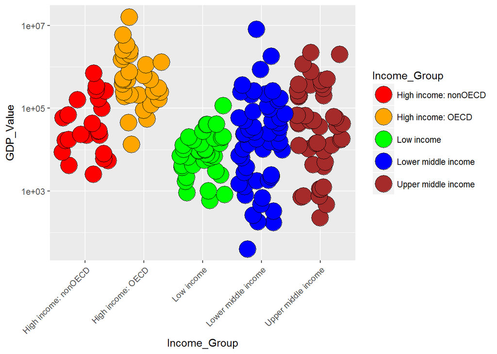

```r
ggplot(merge_GDP_EDU, aes(y = GDP_Value, x=Income_Group,fill=Income_Group)) +
  scale_y_log10()+
  geom_point(pch = 21, size = 8, stat = "identity", position=position_jitter())+
  scale_fill_manual(values = c("red", "orange", "green", "blue","brown"),
                    na.value = "grey50" ) + theme(axis.text.x = element_text(angle = 45, hjust = 1))
```

## Conclusion.

According to The Organization for Economic Cooperation and Development. “OECD member countries account for 63 percent of world GDP, three-quarters of world trade, 95 percent of world official development assistance.”

During our analysis, it was interesting to discover that there are countries that do not fall within the OECD and high income bracket whose GDP is greater than majority of high income and high income OECD countries. To name a few , we see countiries such China,India,Indonesia, Nigeria and some others whose GDP is growing by leaps and bounds.

There is no doubt that these middle income countries given the consistent rise in their GDP will one day become the engine of economic growth, prosperity, and sustainable development.